# ClusterAnalysis-HierarchicalMethod

Ben Renne

11 11 2020

### Load Libraries and set working directory

```r
file_base <- "C:/Users/tamta/Documents/Studium/02_Master/17_Masterarbeit/03_Data/"

library(forcats)
library(ecodist)
library(tidyverse)
library(cluster)
library(factoextra)
library(dendextend)
library(magrittr)
```

### Create test data

```r
alter <- c(43, 38, 6, 47, 37, 9)
```

### Perform the Hierarchical Cluster Analysis

First the distance matrix is calculated. Then, a hierarchical clustering analysis is performed. The method allows among others the choice between the single-linkage method, the complete-linkage method and the average-linkage method.

```r
#calculate the discance matrix
d <- dist(alter)
#upper half of the distance matrix
d
```

```
##    1  2  3  4  5
## 2  5
## 3 37 32
## 4  4  9 41
## 5  6  1 31 10
## 6 34 29  3 38 28
```

```r
#hierarchical clustering analysis
e <- hclust(d, method = "complete", members = NULL)
```

### Understand the cluster results

The results of the cluster analysis can be called using the *Dollar* sign. To see how the data is melt together into groups, the **$merge** command show insights. If The row names show the melting levels, the column names the first and second melted element respectively. A negative sign indicates a melting of two objects, a positive sign a melting of two groups (already contain more than one object and are created by melting together two or more objects).

```r
e$merge
```

```
##      [,1] [,2]
## [1,]   -2   -5
## [2,]   -3   -6
## [3,]   -1   -4
## [4,]    1    3
## [5,]    2    4
```

To find out at what distance the objects are melt together, the **$height** command has to be called.

```r
e$height
```

```
## [1]  1  3  4 10 41
```

When it comes to drawing a Dendrogram, the command **$order** indicates in which order the elements have to be drawn that no overlapping would occure.

```r
e$order
```

```
## [1] 3 6 2 5 1 4
```

A Dendrogram itself could be plotted using the following code.

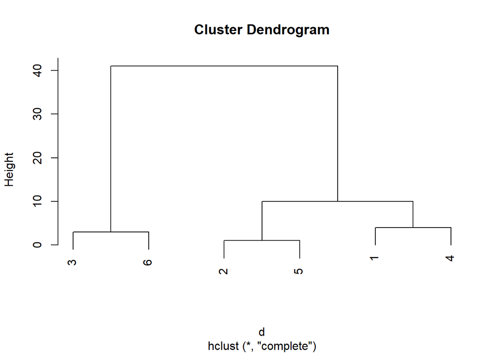

```r
plot(e)
```

### Quality of the results

To evaluate the quality of the generated hierarchical cluster, a cophenetic distance matrix is used and later compared with the full distance matrix (not the half one presented above). To ensure a correct formatting (which is readable in R), the distance matrix has to be transformed.

```r
#generating a cophenetic distance matrix
coph <- cophenetic(e)

#create  full distance matrices for distance matrix and cophenetic distance matrix
dm <- ecodist::full(d)
coph <- full(coph)
```

The two matrices can be used to calculate an empirical correlation coefficient. To do so, a comparison of the full distance matrix and the cophenetic matrix is performed.

```r
#use the values in the lower triangle of the matrices
cor(dm[lower.tri(dm)], coph[lower.tri(coph)])
```

```
## [1] 0.9735457
```

Another method for controlling the results accuracy is the calculation of the Gamma coefficient. Where the Gamma values can be interpreted as follows:

- G >= 0.9 Very good
- G >= 0.8 Good
- G >= 0.7 Fair
- G >= 0.6 Sufficient (*ausreichend*)
- G < 0.6 Poor

```r
#gamma coefficient
gammakoeffizient <- function(v1, v2){
  m1 <- outer(v1, v1, FUN = "<")
  m1 <- m1[lower.tri(m1)]
  m2 <- outer(v2, v2, FUN = "<")
  m2 <- m2[lower.tri(m2)]
  m3 <- outer(v1, v1, FUN = ">")
  m3 <- m3[lower.tri(m3)]
  m4 <- outer(v2, v2, FUN = ">")
  m4 <- m4[lower.tri(m4)]
  C <- sum((m1 + m2) == 2)
  C <- C + sum((m3 + m4) == 2)
  D <- sum((m1 + m4) == 2)
  D <- D + sum((m2 + m3) == 2)
  (C - D)/(C + D)
}

gammakoeffizient(dm[lower.tri(dm)], coph[lower.tri(coph)])
```

```
## [1] 1
```

A third option is to use the *Mojena Test*. It standardize the values and uses a threshold of 1.25 to test how many cluster classes are adequat.

```r
1+sum((e$height-mean(e$height))/sqrt(e$height)>1.25)
```

```
## [1] 2
```

### Visual interpretation

To get a first idea, of how the data is grouped, the result can be visualized with a dendrogram (shown above) and the groups can be marked using the largest height difference.

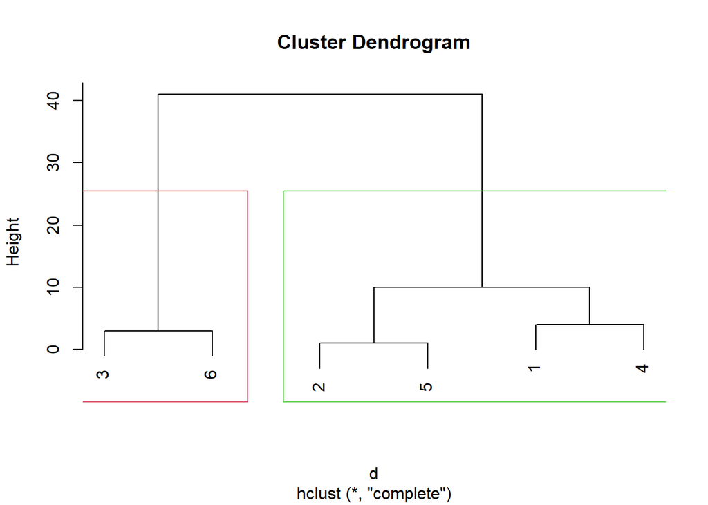

```r
plot(e)
rect.hclust(e, k = 2, border = 2:4)
```

The visual interpretation can be supported by a so-called stair plot (*Treppenplot*). It visualizes the melting levels and the number difference that lies between the unique values of the data.

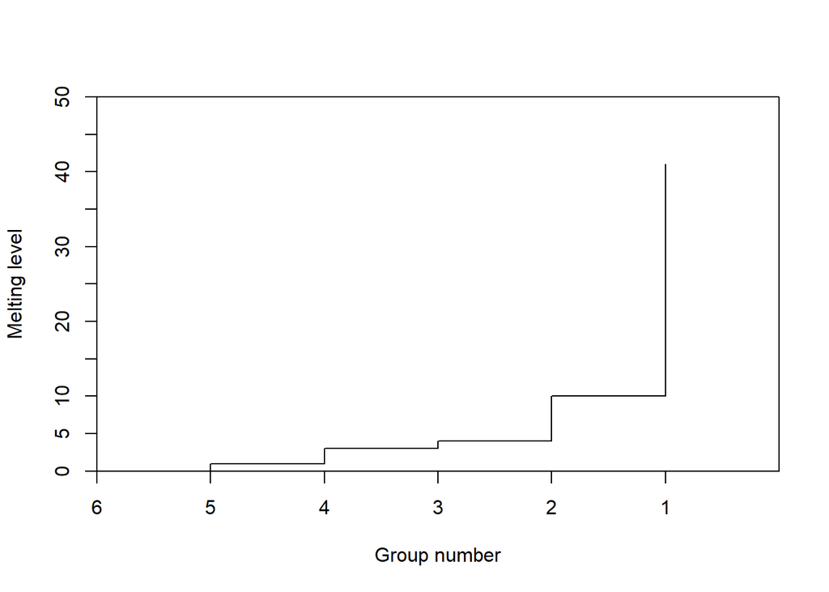

```r
eh <- e$height

#first tick
plot(rep(1,2),c(0,eh[1]),xaxt="n",yaxt="n",xlim=c(0,length(alter)),
     xaxs="i",yaxs="i",ylim=c(0,50),type="l",
     xlab="Group number",ylab="Melting level")
#horizontal lines
for(i in 2:5) lines(c(i,i),c(eh[i-1],eh[i]))
#vetical lines
for (i in seq(1:(length(eh)-1))) lines(c(i,i+1),rep(eh[i],2))
#x axis ticks
axis(1,at=0:5,labels=6:1)
#y axis ticks
axis(2, at = seq(0,50,5), labels = seq(0,50,5))
```

### Find out which group number is most appropriate (only possible for 2D data)

To use the methods, presented in this section, more complex 2D data (dataframe) is necessary. It can used like the 1D data presented above, like using **hclust(df)** or **dist(df)**.

```r
#data of arrests and population density in the USA.
df <- USArrests %>% na.omit() %>% scale()
head(df)
```

```
##                Murder   Assault   UrbanPop         Rape
## Alabama    1.24256408 0.7828393 -0.5209066 -0.003416473
## Alaska     0.50786248 1.1068225 -1.2117642  2.484202941
## Arizona    0.07163341 1.4788032  0.9989801  1.042878388
## Arkansas   0.23234938 0.2308680 -1.0735927 -0.184916602
## California 0.27826823 1.2628144  1.7589234  2.067820292
## Colorado   0.02571456 0.3988593  0.8608085  1.864967207
```

#### 1. Ellbow method

One simple way of testing which group number is appropriate is using the *Ellbow Method*. To do so, the total within-cluster sum of square (wss) has to be as small as possible. The implemented method is presented below.

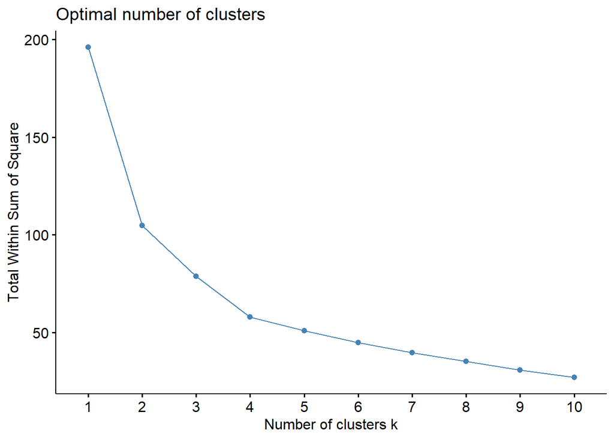

```r
fviz_nbclust(df, FUN = hcut, method = "wss")
```

The result suggests “breaks” at 2 and at 4 classes. That’s where the trend of the data points before and after are disturbed.

#### 2. Average Silhouette method

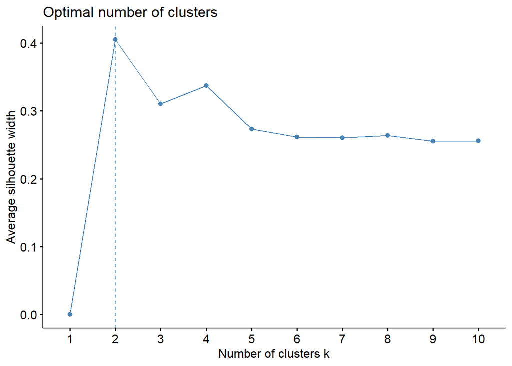

```r
fviz_nbclust(df, FUN = hcut, method = "silhouette")
```

The result suggests “breaks” at 2 and at 4 classes, although 2 classes are the main maxima and 4 classes are the second optimal maxima.

#### 3. Gap statistic method

The gap statistics compares the within-group distance with a distribution that is not clustered. The deviation is presented as gap. As larger the gap value, as more appropriate the group is identified.

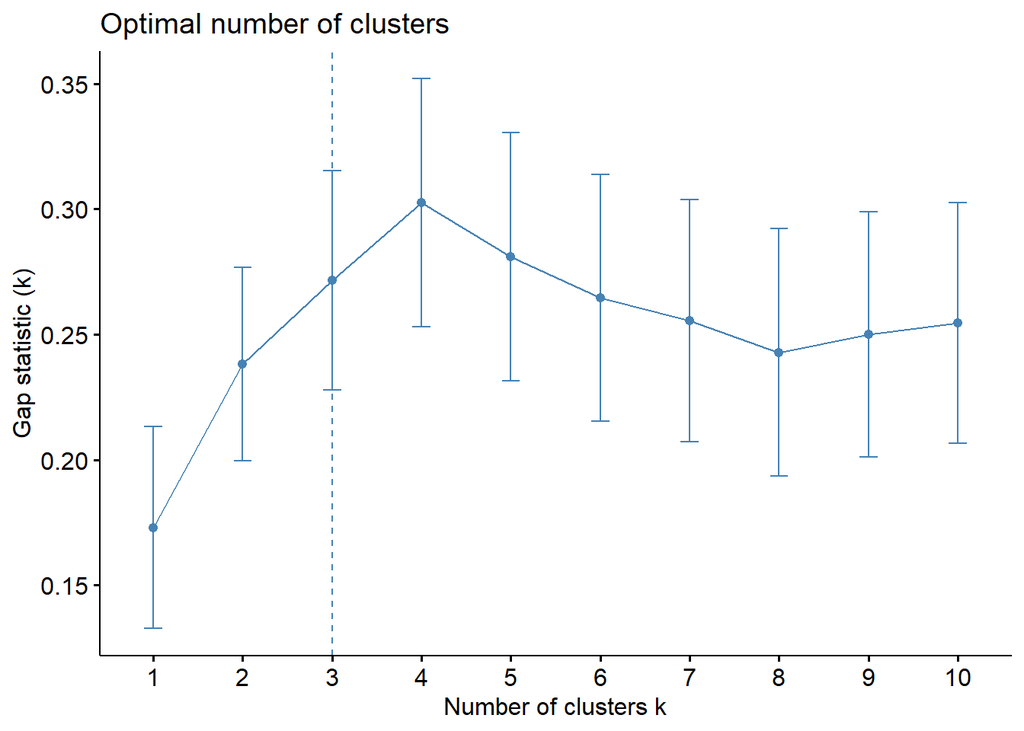

```r
gap_stat <- clusGap(df, FUN = hcut, nstart = 25, K.max = 10, B = 50)
fviz_gap_stat(gap_stat)
```

### Overview categorized variables

Back to 1D data:  
To find out to which groups the data values are assigned, the group number can be derived in the next steps.

```r
#allocate the groups to the data values
welche.cluster <- function(anz, hierar){
  co <- full(cophenetic(hierar))
  h <- hierar$height[length(hierar$height) + 1 - anz]
  n <- ncol(co)
  cl <- rep(0, n)
  k <- 1
  for(i in 1:n) {
    if(cl[i] == 0) {
      ind <- (1:n)[co[i, ] <= h]
      cl[ind] <- k
      k <- k + 1
    }
  }
  cl
}
# fill in the number of distinctive groups and the data
welche.cluster(hierar = e, anz = 2)
print("Respective data values:")
print(alter)
```

```
## [1] 1 1 2 1 1 2
```

```
## [1] "Respective data values:"
```

```
## [1] 43 38  6 47 37  9
```

### Reference

The documentation is based on:

- Handl, A., & Kuhlenkasper, T. (2017). Multivariate Analysemethoden. https://doi.org/10.1007/978-3-662-54754-0 (Kapitel 13 - Clusteranalyse)

Information on how to use more complex data is presented here:

- UC Business Analytics R Programming Guide (2020): K-means Cluster Analysis. https://uc-r.github.io/kmeans_clustering